# Tugas MANOVA

# Introduction

Data Source: [Employee Attrition MANOVA](https://www.kaggle.com/code/duyguatasever/employee-attrition-manova/data)

In Human Resource field, factors that determine its successness is the abililty to attracting and retaining top talent. As an HR personalia, it is my task to determine what factor contribute to employee satisfaction in doing their job.

This dataset consist of employee that either still stay at the company and already leaving given the job satisfaction. The goal is to identify and improve these factor so that it may improve HR performance in terms of gathering top talent and increase the retention by analyzing what factors affecting job satisfaction

```r
attr_raw = read.csv("D:/Kuliah/semester_1/Statistika dan Analisis Multivariat/Pertemuan 15/Tugas/employee_attrition_train.csv")
```

```r
head(attr_raw)
```

|  | Age | Attrition | BusinessTravel | DailyRate | Department | DistanceFromHome | Education | EducationField | EmployeeCount | EmployeeNumber | EnvironmentSatisfaction | Gender | HourlyRate | JobInvolvement | JobLevel | JobRole | JobSatisfaction | MaritalStatus | MonthlyIncome | MonthlyRate | NumCompaniesWorked | Over18 | OverTime | PercentSalaryHike | PerformanceRating | RelationshipSatisfaction | StandardHours | StockOptionLevel | TotalWorkingYears | … |
| --- | --- | --- | --- | --- | --- | --- | --- | --- | --- | --- | --- | --- | --- | --- | --- | --- | --- | --- | --- | --- | --- | --- | --- | --- | --- | --- | --- | --- | --- | --- |
| 1 | 50 | No | Travel_Rarely | 1126 | Research & Development | 1 | 2 | Medical | 1 | 997 | 4 | Male | 66 | 3 | 4 | Research Director | 4 | Divorced | 17399 | 6615 | 9 | Y | No | 22 | 4 | 3 | 80 | 1 | 32 | … |
| 2 | 36 | No | Travel_Rarely | 216 | Research & Development | 6 | 2 | Medical | 1 | 178 | 2 | Male | 84 | 3 | 2 | Manufacturing Director | 2 | Divorced | 4941 | 2819 | 6 | Y | No | 20 | 4 | 4 | 80 | 2 | 7 | … |
| 3 | 21 | Yes | Travel_Rarely | 337 | Sales | 7 | 1 | Marketing | 1 | 1780 | 2 | Male | 31 | 3 | 1 | Sales Representative | 2 | Single | 2679 | 4567 | 1 | Y | No | 13 | 3 | 2 | 80 | 0 | 1 | … |
| 4 | 50 | No | Travel_Frequently | 1246 | Human Resources | NA | 3 | Medical | 1 | 644 | 1 | Male | 99 | 3 | 5 | Manager | 2 | Married | 18200 | 7999 | 1 | Y | No | 11 | 3 | 3 | 80 | 1 | 32 | … |
| 5 | 52 | No | Travel_Rarely | 994 | Research & Development | 7 | 4 | Life Sciences | 1 | 1118 | 2 | Male | 87 | 3 | 3 | Healthcare Representative | 2 | Single | 10445 | 15322 | 7 | Y | No | 19 | 3 | 4 | 80 | 0 | 18 | … |
| 6 | 33 | Yes | Travel_Rarely | 1277 | Research & Development | 15 | 1 | Medical | 1 | 582 | 2 | Male | 56 | 3 | 3 | Manager | 3 | Married | 13610 | 24619 | 7 | Y | Yes | 12 | 3 | 4 | 80 | 0 | 15 | … |

```r
str(attr_raw)
```

```
'data.frame':   1029 obs. of  35 variables:
 $ Age                     : int  50 36 21 50 52 33 47 22 NA 33 ...
 $ Attrition               : chr  "No" "No" "Yes" "No" ...
 $ BusinessTravel          : chr  "Travel_Rarely" "Travel_Rarely" "Travel_Rarely" "Travel_Frequently" ...
 $ DailyRate               : int  1126 216 337 1246 994 1277 1001 1230 890 530 ...
 $ Department              : chr  "Research & Development" "Research & Development" "Sales" "Human Resources" ...
 $ DistanceFromHome        : int  1 6 7 NA 7 15 4 1 2 16 ...
 $ Education               : int  2 2 1 3 4 1 3 2 4 3 ...
 $ EducationField          : chr  "Medical" "Medical" "Marketing" "Medical" ...
 $ EmployeeCount           : int  1 1 1 1 1 1 1 1 1 1 ...
 $ EmployeeNumber          : int  997 178 1780 644 1118 582 1827 872 828 1681 ...
 $ EnvironmentSatisfaction : int  4 2 2 1 2 2 3 4 3 3 ...
 $ Gender                  : chr  "Male" "Male" "Male" "Male" ...
 $ HourlyRate              : int  66 84 31 99 87 56 92 33 46 36 ...
 $ JobInvolvement          : int  3 3 3 3 3 3 2 2 3 3 ...
```

[output cut: 21 more lines]

## Descriptive Statistics

```r
summary(attr_raw)
```

```
      Age         Attrition         BusinessTravel       DailyRate       Department        DistanceFromHome   Education
 Min.   :18.00   Length:1029        Length:1029        Min.   : 102.0   Length:1029        Min.   : 1.00    Min.   :1.000
 1st Qu.:31.00   Class :character   Class :character   1st Qu.: 458.2   Class :character   1st Qu.: 2.00    1st Qu.:2.000
 Median :37.00   Mode  :character   Mode  :character   Median : 801.5   Mode  :character   Median : 8.00    Median :3.000
 Mean   :37.93                                         Mean   : 800.5                      Mean   : 9.93    Mean   :2.892
 3rd Qu.:44.00                                         3rd Qu.:1162.0                      3rd Qu.:16.00    3rd Qu.:4.000
 Max.   :60.00                                         Max.   :1496.0                      Max.   :29.00    Max.   :5.000
 NA's   :136                                           NA's   :27                          NA's   :95
 EducationField     EmployeeCount EmployeeNumber EnvironmentSatisfaction    Gender            HourlyRate     JobInvolvement
 Length:1029        Min.   :1     Min.   :   1   Min.   :1.000           Length:1029        Min.   : 30.00   Min.   :1.000
 Class :character   1st Qu.:1     1st Qu.: 496   1st Qu.:2.000           Class :character   1st Qu.: 48.00   1st Qu.:2.000
 Mode  :character   Median :1     Median :1019   Median :3.000           Mode  :character   Median : 67.00   Median :3.000
                    Mean   :1     Mean   :1024   Mean   :2.683                              Mean   : 66.68   Mean   :2.713
                    3rd Qu.:1     3rd Qu.:1553   3rd Qu.:4.000                              3rd Qu.: 84.00   3rd Qu.:3.000
                    Max.   :1     Max.   :2068   Max.   :4.000                              Max.   :100.00   Max.   :4.000

    JobLevel       JobRole          JobSatisfaction MaritalStatus      MonthlyIncome    MonthlyRate    NumCompaniesWorked
 Min.   :1.000   Length:1029        Min.   :1.000   Length:1029        Min.   : 1009   Min.   : 2094   Min.   :0.000
 1st Qu.:1.000   Class :character   1st Qu.:2.000   Class :character   1st Qu.: 2814   1st Qu.: 7950   1st Qu.:1.000
 Median :2.000   Mode  :character   Median :3.000   Mode  :character   Median : 4735   Median :14295   Median :1.000
 Mean   :2.044                      Mean   :2.712                      Mean   : 6450   Mean   :14251   Mean   :2.653
 3rd Qu.:3.000                      3rd Qu.:4.000                      3rd Qu.: 8446   3rd Qu.:20392   3rd Qu.:4.000
 Max.   :5.000                      Max.   :4.000                      Max.   :19999   Max.   :26999   Max.   :9.000

    Over18            OverTime         PercentSalaryHike PerformanceRating RelationshipSatisfaction StandardHours
 Length:1029        Length:1029        Min.   :11.00     Min.   :3.000     Min.   :1.00             Min.   :80
 Class :character   Class :character   1st Qu.:12.00     1st Qu.:3.000     1st Qu.:2.00             1st Qu.:80
 Mode  :character   Mode  :character   Median :14.00     Median :3.000     Median :3.00             Median :80
                                       Mean   :15.26     Mean   :3.159     Mean   :2.69             Mean   :80
                                       3rd Qu.:18.00     3rd Qu.:3.000     3rd Qu.:4.00             3rd Qu.:80
                                       Max.   :25.00     Max.   :4.000     Max.   :4.00             Max.   :80

 StockOptionLevel TotalWorkingYears TrainingTimesLastYear WorkLifeBalance YearsAtCompany   YearsInCurrentRole
 Min.   :0.0000   Min.   : 0.0      Min.   :0.000         Min.   :1.000   Min.   : 0.000   Min.   : 0.000
 1st Qu.:0.0000   1st Qu.: 6.0      1st Qu.:2.000         1st Qu.:2.000   1st Qu.: 3.000   1st Qu.: 2.000
 Median :1.0000   Median :10.0      Median :3.000         Median :3.000   Median : 5.000   Median : 3.000
 Mean   :0.8222   Mean   :11.2      Mean   :2.782         Mean   :2.748   Mean   : 6.943   Mean   : 4.216
 3rd Qu.:1.0000   3rd Qu.:15.0      3rd Qu.:3.000         3rd Qu.:3.000   3rd Qu.:10.000   3rd Qu.: 7.000
 Max.   :3.0000   Max.   :40.0      Max.   :6.000         Max.   :4.000   Max.   :37.000   Max.   :18.000

 YearsSinceLastPromotion YearsWithCurrManager
 Min.   : 0.00           Min.   : 0.000
 1st Qu.: 0.00           1st Qu.: 2.000
 Median : 1.00           Median : 3.000
 Mean   : 2.12           Mean   : 4.006
 3rd Qu.: 2.00           3rd Qu.: 7.000
 Max.   :15.00           Max.   :17.000
```

## Check for Null Value

```r
lapply(attr_raw, function(x) {length(which(is.na(x)))})
```

```
$Age
[1] 136

$Attrition
[1] 0

$BusinessTravel
[1] 0

$DailyRate
[1] 27

$Department
[1] 0

$DistanceFromHome
[1] 95

$Education
[1] 0

$EducationField
[1] 0

$EmployeeCount
[1] 0

$EmployeeNumber
[1] 0

$EnvironmentSatisfaction
[1] 0

$Gender
[1] 0

$HourlyRate
[1] 0

$JobInvolvement
```

[output cut: 49 more lines]

```

$WorkLifeBalance
[1] 0

$YearsAtCompany
[1] 0

$YearsInCurrentRole
[1] 0

$YearsSinceLastPromotion
[1] 0

$YearsWithCurrManager
[1] 0
```

```r
attr_na = as.data.frame(na.omit(attr_raw))
lapply(attr_na, function(x) {length(which(is.na(x)))})
```

```
$Age
[1] 0

$Attrition
[1] 0

$BusinessTravel
[1] 0

$DailyRate
[1] 0

$Department
[1] 0

$DistanceFromHome
[1] 0

$Education
[1] 0

$EducationField
[1] 0

$EmployeeCount
[1] 0

$EmployeeNumber
[1] 0

$EnvironmentSatisfaction
[1] 0

$Gender
[1] 0

$HourlyRate
[1] 0

$JobInvolvement
```

[output cut: 49 more lines]

```

$WorkLifeBalance
[1] 0

$YearsAtCompany
[1] 0

$YearsInCurrentRole
[1] 0

$YearsSinceLastPromotion
[1] 0

$YearsWithCurrManager
[1] 0
```

## Drop Column with Uniform Value

```r
attr_dc = attr_na[c(-9,-22,-27)]
head(attr_dc)
```

|  | Age | Attrition | BusinessTravel | DailyRate | Department | DistanceFromHome | Education | EducationField | EmployeeNumber | EnvironmentSatisfaction | Gender | HourlyRate | JobInvolvement | JobLevel | JobRole | JobSatisfaction | MaritalStatus | MonthlyIncome | MonthlyRate | NumCompaniesWorked | OverTime | PercentSalaryHike | PerformanceRating | RelationshipSatisfaction | StockOptionLevel | TotalWorkingYears | TrainingTimesLastYear | WorkLifeBalance | YearsAtCompany | … |
| --- | --- | --- | --- | --- | --- | --- | --- | --- | --- | --- | --- | --- | --- | --- | --- | --- | --- | --- | --- | --- | --- | --- | --- | --- | --- | --- | --- | --- | --- | --- |
| 1 | 50 | No | Travel_Rarely | 1126 | Research & Development | 1 | 2 | Medical | 997 | 4 | Male | 66 | 3 | 4 | Research Director | 4 | Divorced | 17399 | 6615 | 9 | No | 22 | 4 | 3 | 1 | 32 | 1 | 2 | 5 | … |
| 2 | 36 | No | Travel_Rarely | 216 | Research & Development | 6 | 2 | Medical | 178 | 2 | Male | 84 | 3 | 2 | Manufacturing Director | 2 | Divorced | 4941 | 2819 | 6 | No | 20 | 4 | 4 | 2 | 7 | 0 | 3 | 3 | … |
| 3 | 21 | Yes | Travel_Rarely | 337 | Sales | 7 | 1 | Marketing | 1780 | 2 | Male | 31 | 3 | 1 | Sales Representative | 2 | Single | 2679 | 4567 | 1 | No | 13 | 3 | 2 | 0 | 1 | 3 | 3 | 1 | … |
| 5 | 52 | No | Travel_Rarely | 994 | Research & Development | 7 | 4 | Life Sciences | 1118 | 2 | Male | 87 | 3 | 3 | Healthcare Representative | 2 | Single | 10445 | 15322 | 7 | No | 19 | 3 | 4 | 0 | 18 | 4 | 3 | 8 | … |
| 6 | 33 | Yes | Travel_Rarely | 1277 | Research & Development | 15 | 1 | Medical | 582 | 2 | Male | 56 | 3 | 3 | Manager | 3 | Married | 13610 | 24619 | 7 | Yes | 12 | 3 | 4 | 0 | 15 | 2 | 4 | 7 | … |
| 7 | 47 | No | Travel_Rarely | 1001 | Research & Development | 4 | 3 | Life Sciences | 1827 | 3 | Female | 92 | 2 | 3 | Manufacturing Director | 2 | Divorced | 10333 | 19271 | 8 | Yes | 12 | 3 | 3 | 1 | 28 | 4 | 3 | 22 | … |

## Data Visualization

```
`guides(<scale> = FALSE)` is deprecated. Please use `guides(<scale> = "none")` instead.
```

| var | frequency | percentage | cumulative_perc |
| --- | --- | --- | --- |
| No | 655 | 83.55 | 83.55 |
| Yes | 129 | 16.45 | 100.00 |

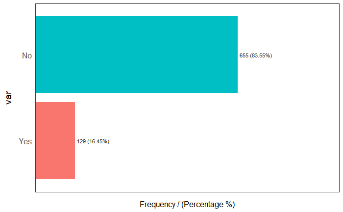

```r
library(funModeling)
freq(attr_dc$Attrition)
```

Here we see greatly imbalance class that favor employee that still on company

```
`guides(<scale> = FALSE)` is deprecated. Please use `guides(<scale> = "none")` instead.
```

| var | frequency | percentage | cumulative_perc |
| --- | --- | --- | --- |
| Sales Executive | 159 | 20.28 | 20.28 |
| Research Scientist | 157 | 20.03 | 40.31 |
| Laboratory Technician | 131 | 16.71 | 57.02 |
| Manufacturing Director | 78 | 9.95 | 66.97 |
| Healthcare Representative | 64 | 8.16 | 75.13 |
| Manager | 63 | 8.04 | 83.17 |
| Research Director | 57 | 7.27 | 90.44 |
| Sales Representative | 51 | 6.51 | 96.95 |
| Human Resources | 24 | 3.06 | 100.00 |

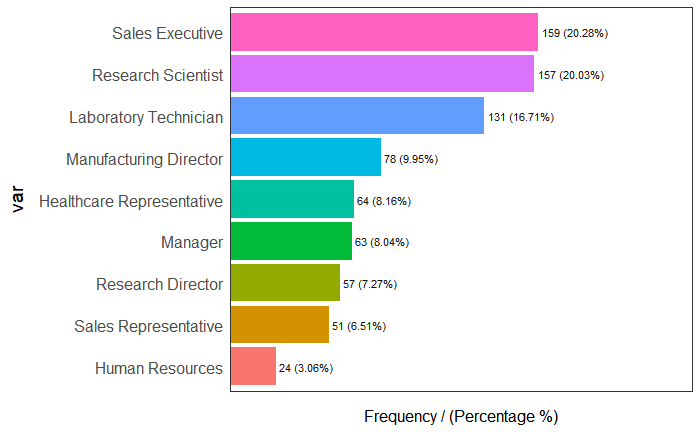

```r
freq(attr_dc$JobRole)
```

Here, there are also imbalance class. Most of the employee working as Sales Executive and Research Scientist.

```
`guides(<scale> = FALSE)` is deprecated. Please use `guides(<scale> = "none")` instead.
```

| var | frequency | percentage | cumulative_perc |
| --- | --- | --- | --- |
| 4 | 246 | 31.38 | 31.38 |
| 3 | 228 | 29.08 | 60.46 |
| 2 | 164 | 20.92 | 81.38 |
| 1 | 146 | 18.62 | 100.00 |

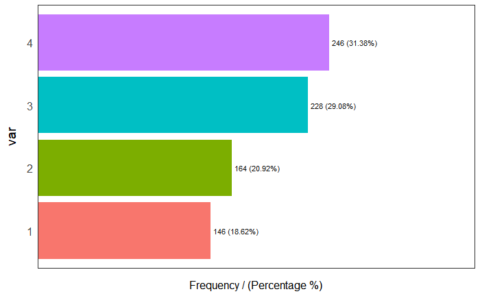

```r
freq(attr_dc$JobSatisfaction)
```

Here, most of the employee satisfied with their job on the company, but nonetheless, there are lots of dissatisfaction.

```
`guides(<scale> = FALSE)` is deprecated. Please use `guides(<scale> = "none")` instead.
```

| var | frequency | percentage | cumulative_perc |
| --- | --- | --- | --- |
| Male | 465 | 59.31 | 59.31 |
| Female | 319 | 40.69 | 100.00 |

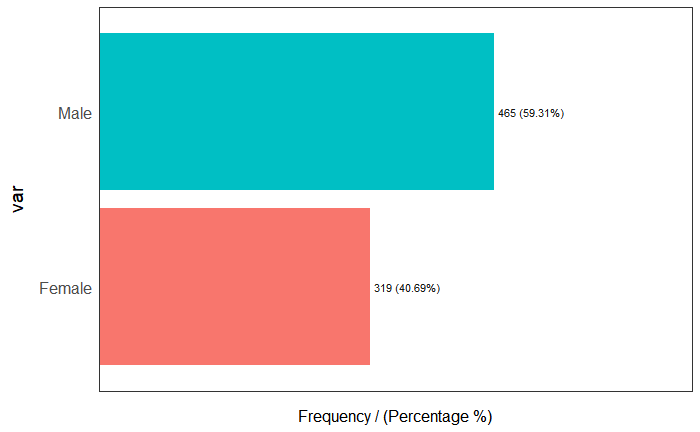

```r
freq(attr_dc$Gender)
```

Here, the gender in this company is quite balance with male dominating

```
`guides(<scale> = FALSE)` is deprecated. Please use `guides(<scale> = "none")` instead.
```

| var | frequency | percentage | cumulative_perc |
| --- | --- | --- | --- |
| Married | 363 | 46.30 | 46.30 |
| Single | 243 | 30.99 | 77.29 |
| Divorced | 173 | 22.07 | 99.36 |
|  | 5 | 0.64 | 100.00 |

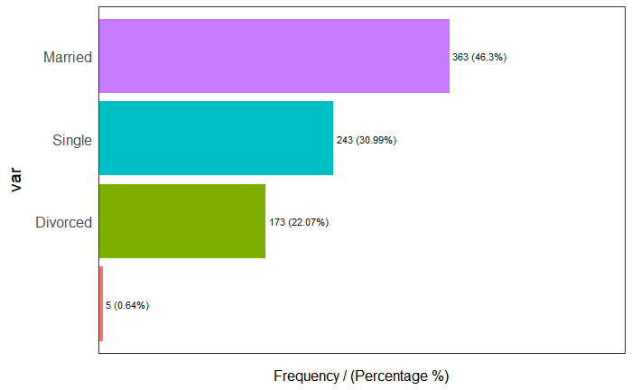

```r
freq(attr_na$MaritalStatus)
```

Bar plot of count education field in terms of gender

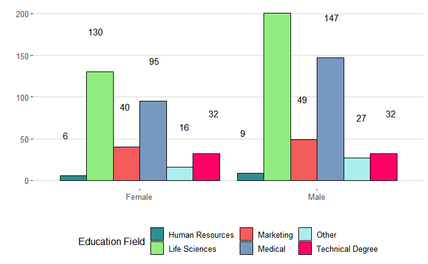

```r
library(dplyr)
#install.packages("ggthemes")
library(ggthemes)
attr_dc %>%
  count(Gender, EducationField)%>%
  ggplot(aes(x=Gender, y=n, fill=EducationField))+
  geom_bar(stat='identity', position='dodge', col='black')+
  theme_hc()+
  scale_fill_hc('darkunica')+
  labs(x='', y='', fill='Education Field')+
  geom_text(aes(label=n), position=position_dodge(width=1), vjust=-5)
```

```r
library("rstatix")
attr_dc%>%
  group_by(JobRole) %>%
  get_summary_stats(Age, DailyRate, MonthlyIncome, type="mean_sd")
```

| JobRole | variable | n | mean | sd |
| --- | --- | --- | --- | --- |
| Healthcare Representative | Age | 64 | 40.375 | 7.965 |
| Healthcare Representative | DailyRate | 64 | 881.281 | 402.585 |
| Healthcare Representative | MonthlyIncome | 64 | 7377.891 | 2456.170 |
| Human Resources | Age | 24 | 36.458 | 8.330 |
| Human Resources | DailyRate | 24 | 780.458 | 452.167 |
| Human Resources | MonthlyIncome | 24 | 4079.875 | 2765.235 |
| Laboratory Technician | Age | 131 | 35.130 | 8.975 |
| Laboratory Technician | DailyRate | 131 | 758.176 | 426.914 |
| Laboratory Technician | MonthlyIncome | 131 | 3180.588 | 1052.374 |
| Manager | Age | 63 | 47.222 | 6.627 |

[output cut: 17 more lines]

```r
attr_dc %>%
  group_by(JobRole) %>%
  summarise(N=n())
```

| JobRole | N |
| --- | --- |
| Healthcare Representative | 64 |
| Human Resources | 24 |
| Laboratory Technician | 131 |
| Manager | 63 |
| Manufacturing Director | 78 |
| Research Director | 57 |
| Research Scientist | 157 |
| Sales Executive | 159 |
| Sales Representative | 51 |

There is an imbalance value within job role, this may cause deviations in MANOVA basic assumptions, so here, lets focus on JobRole that similar

```r
library(dplyr)
attr_im = attr_dc%>%
  filter (JobRole %in% c("Healthcare Representative", "Manager", "Manufacturing Director", "Research Director", "Sales Representative"))
unique(attr_im$JobRole)
```

```
[1] "Research Director"         "Manufacturing Director"    "Sales Representative"      "Healthcare Representative"
[5] "Manager"
```

```r
levels(attr_im$Education)<-c("Below College","College","Bachelor", "Master", "Doctor")
levels(attr_im$EnvironmentSatisfaction)<-c("Low","Medium", "High", "Very High")
levels(attr_im$JobInvolvement)<- c("Low","Medium", "High", "Very High")
levels(attr_im$JobSatisfaction)<-c("Low","Medium", "High", "Very High")
levels(attr_im$PerformanceRating)<-c("Low","Good", "Excellent", "Outstanding")
levels(attr_im$RelationshipSatisfaction)<-c("Low","Medium", "High", "Very High")
levels(attr_im$WorkLifeBalance)<-c("Bad","Good", "Better", "Best")
```

```r
attr_im$Attrition<- as.factor(attr_im$Attrition)
attr_im$BusinessTravel<- as.factor(attr_im$BusinessTravel)
attr_im$Department<-as.factor(attr_im$Department)
attr_im$EducationField<-as.factor(attr_im$EducationField)
attr_im$Gender<-as.factor(attr_im$Gender)
attr_im$JobRole<-as.factor(attr_im$JobRole)
attr_im$MaritalStatus<-as.factor(attr_im$MaritalStatus)
attr_im$OverTime<-as.factor(attr_im$OverTime)
attr_im$Education<-as.factor(attr_im$Education)
attr_im$EnvironmentSatisfaction<- as.factor(attr_im$EnvironmentSatisfaction)
attr_im$JobInvolvement<- as.factor(attr_im$JobInvolvement)
attr_im$JobSatisfaction<- as.factor(attr_im$JobSatisfaction)
attr_im$RelationshipSatisfaction<- as.factor(attr_im$RelationshipSatisfaction)
attr_im$PerformanceRating<- as.factor(attr_im$PerformanceRating)
attr_im$WorkLifeBalance<- as.factor(attr_im$WorkLifeBalance)
```

```r
head(attr_im)
```

|  | Age | Attrition | BusinessTravel | DailyRate | Department | DistanceFromHome | Education | EducationField | EmployeeNumber | EnvironmentSatisfaction | Gender | HourlyRate | JobInvolvement | JobLevel | JobRole | JobSatisfaction | MaritalStatus | MonthlyIncome | MonthlyRate | NumCompaniesWorked | OverTime | PercentSalaryHike | PerformanceRating | RelationshipSatisfaction | StockOptionLevel | TotalWorkingYears | TrainingTimesLastYear | WorkLifeBalance | YearsAtCompany | … |
| --- | --- | --- | --- | --- | --- | --- | --- | --- | --- | --- | --- | --- | --- | --- | --- | --- | --- | --- | --- | --- | --- | --- | --- | --- | --- | --- | --- | --- | --- | --- |
| 1 | 50 | No | Travel_Rarely | 1126 | Research & Development | 1 | 2 | Medical | 997 | 4 | Male | 66 | 3 | 4 | Research Director | 4 | Divorced | 17399 | 6615 | 9 | No | 22 | 4 | 3 | 1 | 32 | 1 | 2 | 5 | … |
| 2 | 36 | No | Travel_Rarely | 216 | Research & Development | 6 | 2 | Medical | 178 | 2 | Male | 84 | 3 | 2 | Manufacturing Director | 2 | Divorced | 4941 | 2819 | 6 | No | 20 | 4 | 4 | 2 | 7 | 0 | 3 | 3 | … |
| 3 | 21 | Yes | Travel_Rarely | 337 | Sales | 7 | 1 | Marketing | 1780 | 2 | Male | 31 | 3 | 1 | Sales Representative | 2 | Single | 2679 | 4567 | 1 | No | 13 | 3 | 2 | 0 | 1 | 3 | 3 | 1 | … |
| 4 | 52 | No | Travel_Rarely | 994 | Research & Development | 7 | 4 | Life Sciences | 1118 | 2 | Male | 87 | 3 | 3 | Healthcare Representative | 2 | Single | 10445 | 15322 | 7 | No | 19 | 3 | 4 | 0 | 18 | 4 | 3 | 8 | … |
| 5 | 33 | Yes | Travel_Rarely | 1277 | Research & Development | 15 | 1 | Medical | 582 | 2 | Male | 56 | 3 | 3 | Manager | 3 | Married | 13610 | 24619 | 7 | Yes | 12 | 3 | 4 | 0 | 15 | 2 | 4 | 7 | … |
| 6 | 47 | No | Travel_Rarely | 1001 | Research & Development | 4 | 3 | Life Sciences | 1827 | 3 | Female | 92 | 2 | 3 | Manufacturing Director | 2 | Divorced | 10333 | 19271 | 8 | Yes | 12 | 3 | 3 | 1 | 28 | 4 | 3 | 22 | … |

## Explore data profile after filtering

```r
attr_im %>%
  group_by(JobSatisfaction) %>%
  summarise(N = n())
```

| JobSatisfaction | N |
| --- | --- |
| 1 | 55 |
| 2 | 66 |
| 3 | 95 |
| 4 | 97 |

```r
attr_im %>%
  group_by(JobSatisfaction)%>%
  summarise(N =n())
```

| JobSatisfaction | N |
| --- | --- |
| 1 | 55 |
| 2 | 66 |
| 3 | 95 |
| 4 | 97 |

```
`guides(<scale> = FALSE)` is deprecated. Please use `guides(<scale> = "none")` instead.
```

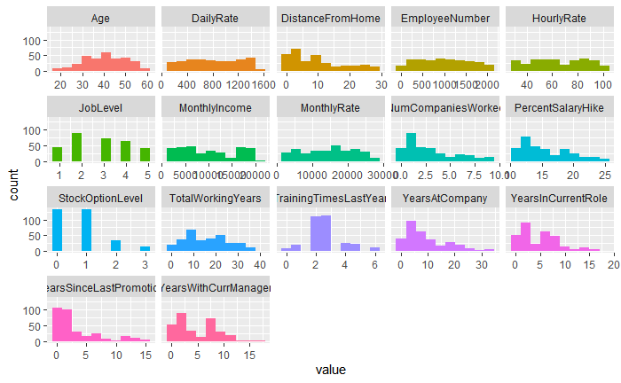

```r
plot_num(attr_im)
```

```r
attr_im %>%
  group_by(JobRole)%>%
  get_summary_stats(Age, DailyRate, MonthlyIncome, type="mean_sd")
```

| JobRole | variable | n | mean | sd |
| --- | --- | --- | --- | --- |
| Healthcare Representative | Age | 64 | 40.375 | 7.965 |
| Healthcare Representative | DailyRate | 64 | 881.281 | 402.585 |
| Healthcare Representative | MonthlyIncome | 64 | 7377.891 | 2456.170 |
| Manager | Age | 63 | 47.222 | 6.627 |
| Manager | DailyRate | 63 | 801.365 | 453.417 |
| Manager | MonthlyIncome | 63 | 17343.889 | 2033.344 |
| Manufacturing Director | Age | 78 | 39.077 | 8.940 |
| Manufacturing Director | DailyRate | 78 | 808.705 | 379.739 |
| Manufacturing Director | MonthlyIncome | 78 | 7459.397 | 2827.267 |
| Research Director | Age | 57 | 44.474 | 7.623 |

[output cut: 5 more lines]

```r
attr_im %>%
  group_by(JobSatisfaction)%>%
  get_summary_stats(Age, DailyRate, MonthlyIncome, type="mean_sd")
```

| JobSatisfaction | variable | n | mean | sd |
| --- | --- | --- | --- | --- |
| 1 | Age | 55 | 39.491 | 9.771 |
| 1 | DailyRate | 55 | 825.836 | 395.525 |
| 1 | MonthlyIncome | 55 | 10376.473 | 5918.885 |
| 2 | Age | 66 | 40.924 | 9.894 |
| 2 | DailyRate | 66 | 759.818 | 429.074 |
| 2 | MonthlyIncome | 66 | 10555.621 | 6372.049 |
| 3 | Age | 95 | 40.253 | 9.428 |
| 3 | DailyRate | 95 | 874.021 | 404.607 |
| 3 | MonthlyIncome | 95 | 9957.358 | 6000.569 |
| 4 | Age | 97 | 41.237 | 9.703 |

[output cut: 2 more lines]

```r
str(attr_im$JobInvolvement)
```

```
 Factor w/ 4 levels "1","2","3","4": 3 3 3 3 3 2 2 3 2 3 ...
```

## MANOVA

### One Way Manova

#### Inspect Based on Job Satisfaction

Assumptions:

1. Multivariate normality
2. Equality of intergroup variance covariance matrix

So here, we first examine multivariate normality assumption

**Hypotheses:**

H0: The distribution of the data conforms to the multivariate normal distribution

H1: The distribution of the data does not fit the multivariate normal distribution

```r
attr_im %>%
  select(Age, DistanceFromHome, MonthlyRate)%>%
  mshapiro_test()
```

| statistic | p.value |
| --- | --- |
| 0.9918125 | 0.08117962 |

Since the p-value >0.05, H0 is accepted. The data fit the multivariate normal distribution

Next, we examining the assumption of homogeneity of variance covariance metrics using box_m

**Hypothesis:**

H0 : the variance covariance matrices between the groups are equal

H1 : The variance and covariance matrices between the groups are not equal

```r
box_m(attr_im[,c("Age", "DistanceFromHome", "MonthlyRate")], attr_im$JobSatisfaction)
```

| statistic | p.value | parameter | method |
| --- | --- | --- | --- |
| 11.20455 | 0.8854757 | 18 | Box's M-test for Homogeneity of Covariance Matrices |

Since the p-value is > 0.05, Ho Hypothesis is accepted, therefore the variance covariance matrices between groups are equal.

Next, lets examine the data using levene test, here, we examine whether the variances between the groups are equal.

**Hypotheses :**

H0 : The variance between groups is equal

H1 : The variance between groups is not equal

```r
levene_test(Age~JobSatisfaction, data=attr_im, center=mean)
```

| df1 | df2 | statistic | p |
| --- | --- | --- | --- |
| 3 | 309 | 0.2629463 | 0.8520708 |

Since the p-value is >0.05, H0 hypotheses is accepted, meaning that the variance between groups is equal

Once again we do levene test for DistanceFromHome

**Hypotheses :**

H0 : The variance between groups is equal

H1 : The variance between groups is not equal

```r
levene_test(DistanceFromHome~JobSatisfaction, data=attr_im, center=mean)
```

| df1 | df2 | statistic | p |
| --- | --- | --- | --- |
| 3 | 309 | 2.198616 | 0.08821607 |

Since the p-value is >0.05, H0 hypotheses is accepted, meaning that the variance between groups is equal

Last, we do levene test for MonthlyRate

**Hypotheses :**

H0 : The variance between groups is equal

H1 : The variance between groups is not equal

```r
levene_test(MonthlyRate~JobSatisfaction, data=attr_im, center=mean)
```

| df1 | df2 | statistic | p |
| --- | --- | --- | --- |
| 3 | 309 | 0.7868381 | 0.502002 |

Since the p-value is >0.05, H0 hypotheses is accepted, meaning that the variance between groups is equal

Therefore, this has confirming that all dependent variables are having equal variance between groups of independent variable

Calculate mean Age for each class in JobSatisfaction

```r
means_job_age = aggregate(attr_im$Age , list(attr_im$JobSatisfaction), mean)
means_job_age
```

| Group.1 | x |
| --- | --- |
| 1 | 39.49091 |
| 2 | 40.92424 |
| 3 | 40.25263 |
| 4 | 41.23711 |

```r
means_job_distance = aggregate(attr_im$DistanceFromHome, list(attr_im$JobSatisfaction), mean)
means_job_distance
```

| Group.1 | x |
| --- | --- |
| 1 | 8.236364 |
| 2 | 8.939394 |
| 3 | 10.294737 |
| 4 | 9.907216 |

```r
means_job_rate = aggregate(attr_im$MonthlyRate, list(attr_im$JobSatisfaction), mean)
means_job_rate
```

| Group.1 | x |
| --- | --- |
| 1 | 14353.75 |
| 2 | 14644.82 |
| 3 | 14791.29 |
| 4 | 14708.72 |

Plotting job satisfaction by age

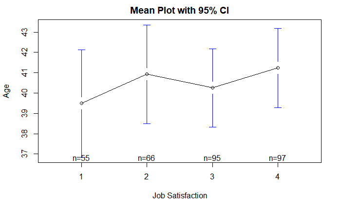

```r
library(gplots)
plotmeans(attr_im$Age~ attr_im$JobSatisfaction, xlab="Job Satisfaction", ylab="Age", main="Mean Plot with 95% CI")
```

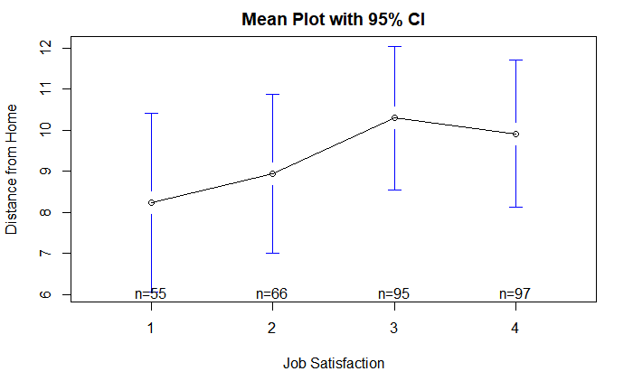

```r
plotmeans(attr_im$DistanceFromHome~ attr_im$JobSatisfaction, xlab="Job Satisfaction", ylab="Distance from Home", main="Mean Plot with 95% CI")
```

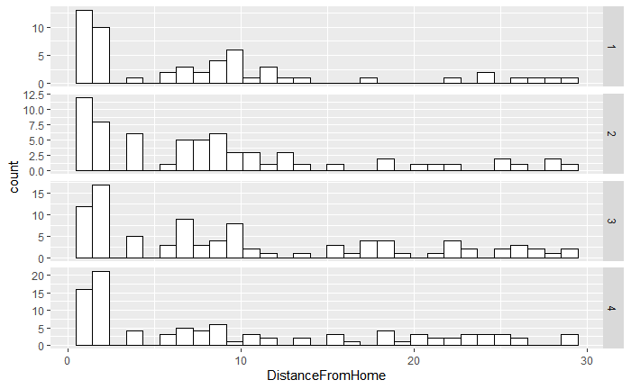

```r
ggplot(attr_im, aes(x = DistanceFromHome)) +
  geom_histogram(fill = "white", colour = "black") +
  facet_grid(JobSatisfaction ~ ., scales = "free")
```

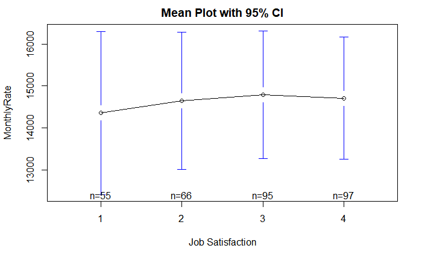

```r
plotmeans(attr_im$MonthlyRate~ attr_im$JobSatisfaction, xlab="Job Satisfaction", ylab="MonthlyRate", main="Mean Plot with 95% CI")
```

#### Peek Age, Distance from Home, and Monthly Rate based on Job Role

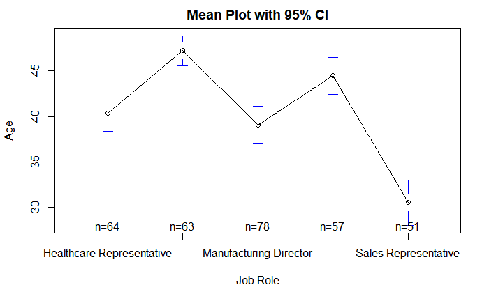

```r
plotmeans(attr_im$Age~ attr_im$JobRole, xlab="Job Role", ylab="Age", main="Mean Plot with 95% CI")
```

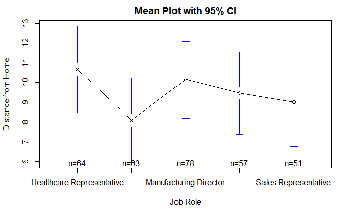

```r
plotmeans(attr_im$DistanceFromHome~ attr_im$JobRole, xlab="Job Role", ylab="Distance from Home", main="Mean Plot with 95% CI")
```

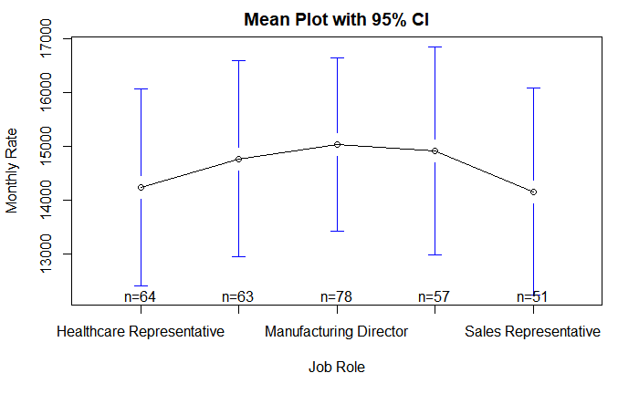

```r
plotmeans(attr_im$MonthlyRate~ attr_im$JobRole, xlab="Job Role", ylab="Monthly Rate", main="Mean Plot with 95% CI")
```

### MANOVA

```r
job_manova = manova(cbind(Age, DistanceFromHome, MonthlyRate)~JobSatisfaction, data=attr_im)
summary(job_manova, test="Wilks")
```

```
                 Df   Wilks approx F num Df den Df Pr(>F)
JobSatisfaction   3 0.98714   0.4427      9 747.31 0.9119
Residuals       309
```

**Hypotheses:**

H0: There is no significant difference between the groups in terms of the dependent variable

H1: There is significant difference between the groups in terms of the dependent variable

```r
summary.aov(job_manova)
```

```
 Response Age :
                 Df  Sum Sq Mean Sq F value Pr(>F)
JobSatisfaction   3   125.1  41.686  0.4455 0.7206
Residuals       309 28911.8  93.566

 Response DistanceFromHome :
                 Df  Sum Sq Mean Sq F value Pr(>F)
JobSatisfaction   3   184.4  61.474  0.8642   0.46
Residuals       309 21981.6  71.138

 Response MonthlyRate :
                 Df     Sum Sq  Mean Sq F value Pr(>F)
JobSatisfaction   3 7.0403e+06  2346775  0.0455 0.9871
Residuals       309 1.5936e+10 51571427
```

Since the p-value are >0.008, the H0 hypothesis is accepted meaning that there are no significant difference between groups in terms of dependent variables

**Multiple Comparison**

for the age variable:

**Hypothesis**

H0: There is no significant difference between the variables

H1: There is a significant difference between the variables

```r
tatmin_aov <- aov(Age ~ JobSatisfaction, data =attr_im)
TukeyHSD(tatmin_aov, "JobSatisfaction")
```

```
  Tukey multiple comparisons of means
    95% family-wise confidence level

Fit: aov(formula = Age ~ JobSatisfaction, data = attr_im)

$JobSatisfaction
          diff       lwr      upr     p adj
2-1  1.4333333 -3.128438 5.995104 0.8489635
3-1  0.7617225 -3.471749 4.995194 0.9666676
4-1  1.7462043 -2.471234 5.963642 0.7083779
3-2 -0.6716108 -4.675419 3.332197 0.9727059
4-2  0.3128710 -3.673981 4.299723 0.9970473
4-3  0.9844818 -2.622111 4.591074 0.8950334
```

Since the p-value >0.05, the H0 is accepted so there is no statistically significance different

for the DistanceFromHome variable:

**Hypothesis**

H0: There is no significant difference between the variables

H1: There is a significant difference between the variables

```r
tatmin_aov <- aov(DistanceFromHome ~ JobSatisfaction, data =attr_im)
TukeyHSD(tatmin_aov, "JobSatisfaction")
```

```
  Tukey multiple comparisons of means
    95% family-wise confidence level

Fit: aov(formula = DistanceFromHome ~ JobSatisfaction, data = attr_im)

$JobSatisfaction
          diff       lwr      upr     p adj
2-1  0.7030303 -3.274607 4.680667 0.9683163
3-1  2.0583732 -1.633003 5.749749 0.4751553
4-1  1.6708529 -2.006543 5.348249 0.6439606
3-2  1.3553429 -2.135779 4.846464 0.7478722
4-2  0.9678226 -2.508514 4.444159 0.8894413
4-3 -0.3875203 -3.532289 2.757249 0.9888239
```

Since the p-value >0.05, the H0 is accepted so there is no statistically significance different

for the MonthlyRate variable:

**Hypothesis**

H0: There is no significant difference between the variables

H1: There is a significant difference between the variables

```r
tatmin_aov <- aov(MonthlyRate ~ JobSatisfaction, data =attr_im)
TukeyHSD(tatmin_aov, "JobSatisfaction")
```

```
  Tukey multiple comparisons of means
    95% family-wise confidence level

Fit: aov(formula = MonthlyRate ~ JobSatisfaction, data = attr_im)

$JobSatisfaction
         diff       lwr      upr     p adj
2-1 291.07273 -3095.648 3677.793 0.9961333
3-1 437.54928 -2705.437 3580.535 0.9840534
4-1 354.97619 -2776.107 3486.059 0.9912456
3-2 146.47656 -2826.005 3118.958 0.9992620
4-2  63.90347 -2895.989 3023.796 0.9999376
4-3 -82.57309 -2760.156 2595.010 0.9998184
```

Since the p-value >0.05, the H0 is accepted so there is no statistically significance different

From the analysis that involve

- Dependent Variables: Age, MonthlyRate, and DistanceFromHome
- Independent Variable: Job Satisfaction

Job satisfaction doesnt being affected by Age, Monthly Rate, nor Distance From Home